# Final Project 2: R Markdown

## Figure 3 - Cancer prevalence by sleep duration and sex

Figure 3 presents the proportion of participants reporting a cancer diagnosis within each weekday sleep category, stratified by sex.

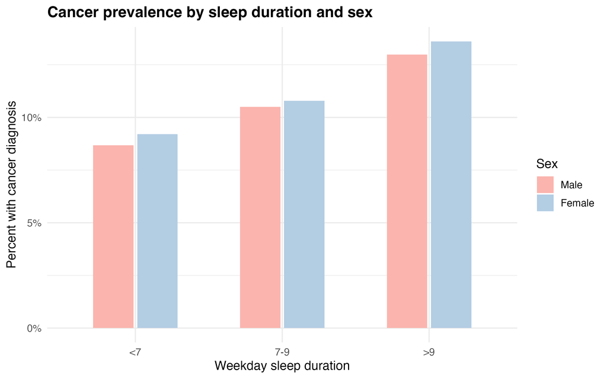

In figure 3, cancer prevalence appeared somewhat higher among those reporting more than 9 hours of sleep in both men and women, with smaller differences observed between shorter and recommended sleep groups. Sex-specific differences within each sleep category were modest.

## Figure 4 - Weekday Sleep Duration by Self-Reported Cancer Site

To further explore heterogeneity, we examined weekday sleep duration patterns by self-reported cancer site among participants with a cancer diagnosis.

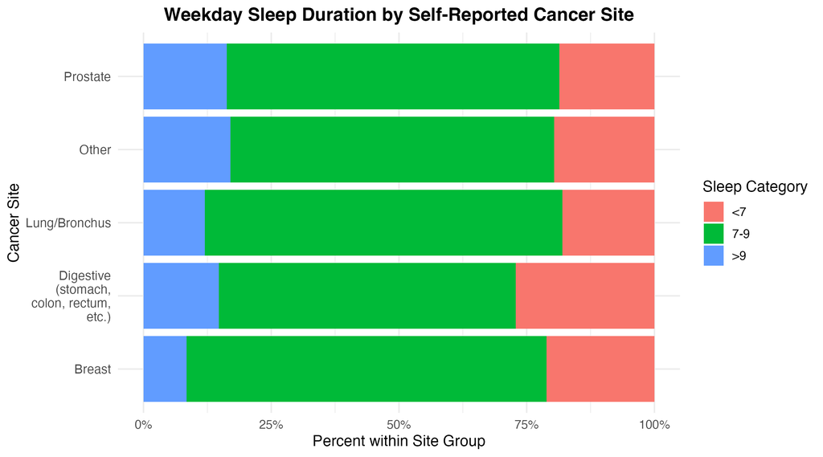

# Conclusions